# The QI Equation: Two Complementary Views

Why the Next Generation of Brain-Computer Interfaces Needs Quantum-Aware Protection

Author

Kevin Qi, with Claude (Anthropic)

Published

February 2, 2026

## 1 Why Two Equations?

The QI equation is presented in two complementary forms:

- **Candidate 1 (Additive/Engineering):** Modular, intuitive, each term independently computable. For BCI engineers building real systems.
- **Candidate 2 (Tensor/Theoretical):** Mathematically rigorous, entanglement natural, decoherence emergent. For physicists evaluating the framework.

Both produce compatible security assessments. They are two lenses on the same reality.

## 2 Candidate 1: The Engineering Equation

$$QI(t) = \alpha \cdot C_{class} + \beta \cdot (1 - \Gamma_D(t)) \cdot [Q_i + \delta \cdot Q_{entangle}] - \gamma \cdot Q_{tunnel}$$

where $\Gamma_D(t) = 1 - e^{-t/\tau_D}$

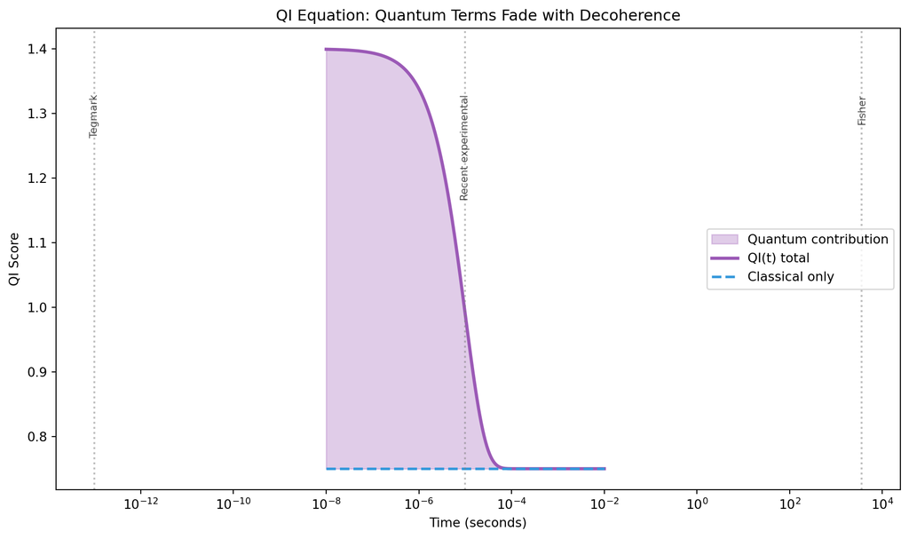

Figure 1: QI score over time: quantum terms fade as decoherence progresses. The shaded region shows the quantum contribution — it’s strongest when t << τ_D and vanishes as the system decoheres.

### 2.1 Live Computation Demo

Change any input and the QI score updates:

Table 1: QI Equation Output Across Decoherence Timescales

|  | Camp | τ_D | Quantum Gate | QI Score |
| --- | --- | --- | --- | --- |
| 0 | Tegmark (skeptic) | 10⁻¹³ s | 0.0000 | 0.7500 |
| 1 | Recent experimental | 10⁻⁵ s | 0.9048 | 1.3381 |
| 2 | Fisher (optimist) | Hours | 1.0000 | 1.4000 |

## 3 Candidate 2: The Theoretical Equation

$$QI = C_{class} \otimes e^{-S_{quantum}}$$

where $S_{quantum} = S_{vN}(\rho(t)) + \lambda \cdot \Phi_{tunnel} - \mu \cdot E(\rho_{AB})$

The security metric is: $S_{QI} = \text{Tr}(\hat{QI} \cdot \rho_{total})$

## 4 Comparing the Two Candidates

Table 2: Candidate Comparison

|  | Property | Candidate 1 (Additive) | Candidate 2 (Tensor) |
| --- | --- | --- | --- |
| 0 | Audience | BCI engineers | Physicists, theorists |
| 1 | Structure | Sum of terms | Tensor product |
| 2 | Decoherence | Explicit gate ΓD(t) | Emerges from SvN(ρ(t)) |
| 3 | Entanglement | Added term (δ·Qentangle) | Natural via E(ρAB) |
| 4 | Calibration params | 4 (α, β, γ, δ) | 2 (λ, μ) |
| 5 | Measurability | Each term independent | Requires state tomography |
| 6 | Computational cost | Low | High |
| 7 | Intuition | High | Low (requires QM background) |

## 5 Sensitivity Analysis

Which parameters drive the QI score most? A one-at-a-time sensitivity analysis sweeps each parameter ±50% from baseline while holding all others constant.

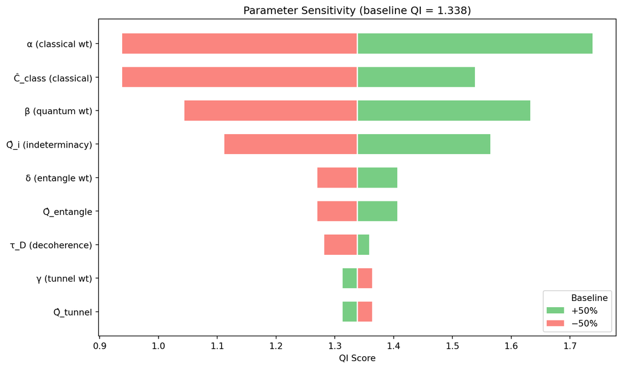

Figure 2: Tornado plot: sensitivity of QI score to ±50% parameter variation. Longer bars indicate parameters that most strongly influence the security assessment.

### 5.1 Decoherence Time vs Elapsed Time

The core physics question — does quantum protection survive long enough to matter? This heatmap shows QI as a function of both τ_D (decoherence time) and t (elapsed time since state preparation).

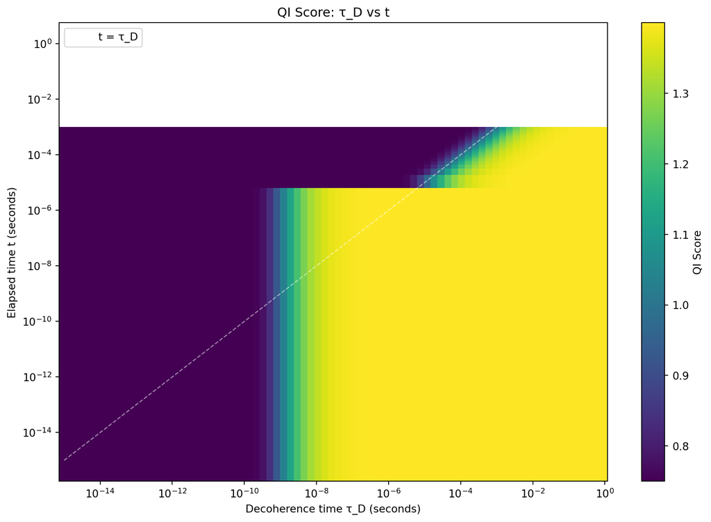

### 5.2 Classical vs Quantum Weight Trade-off

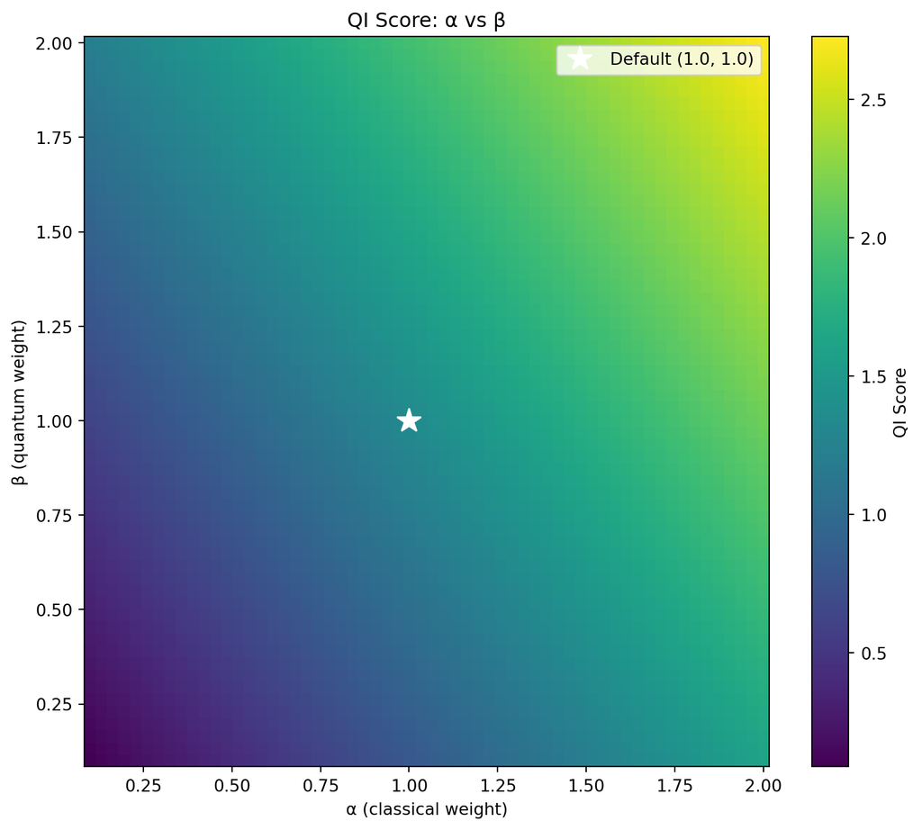

Figure 4: Heatmap: QI score as α (classical weight) and β (quantum weight) vary. The balance between classical and quantum contributions determines overall security posture.

**ImportantKey Finding**

The QI score is most sensitive to **Ĉ_class** (the classical coherence metric) and **α** (its weight), confirming that classical signal integrity is the foundation of the framework. The quantum terms provide additional security margin when decoherence times are favorable, but the classical baseline dominates. **Experimental priority: determine τ_D in vivo** — this single measurement would most dramatically narrow the framework’s uncertainty.